# Project 2: Modeling, Testing, and Predicting

## 2. Randomization test

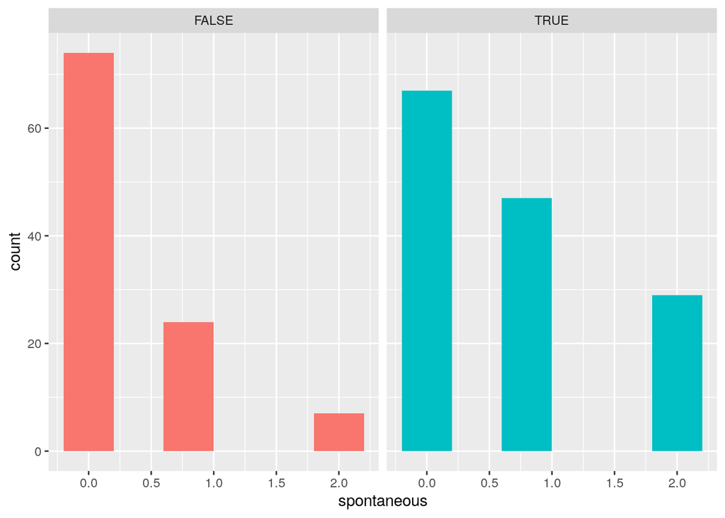

```r
ggplot(abortData, aes(spontaneous, fill = tfinduced)) + geom_histogram(bins = 6.5) +
    facet_wrap(~tfinduced, ncol = 2) + theme(legend.position = "none")
```

```r
mean(abortData[abortData$tfinduced == FALSE, ]$spontaneous) -
    mean(abortData[abortData$tfinduced == TRUE, ]$spontaneous)
```

```
## [1] -0.372361
```

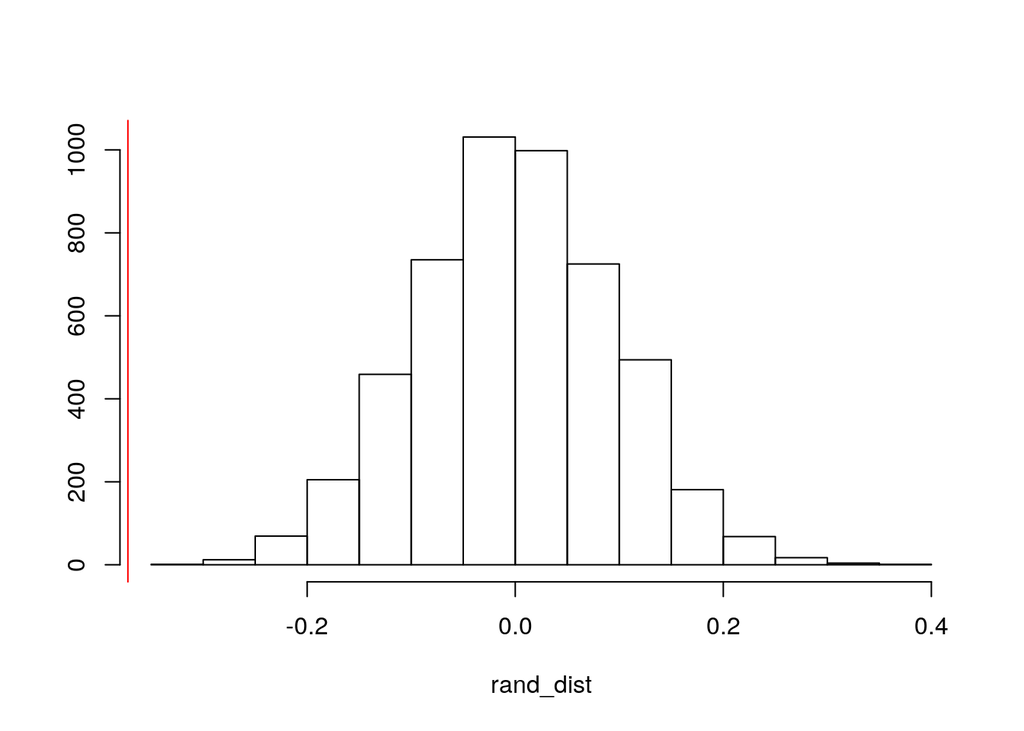

```r
rand_dist <- vector()
for (i in 1:5000) {
    new <- data.frame(spontaneous = sample(abortData$spontaneous),
        induced = abortData$tfinduced)
    rand_dist[i] <- mean(new[new$induced == FALSE, ]$spontaneous) -
        mean(new[new$induced == TRUE, ]$spontaneous)
}
hist(rand_dist, main = "", ylab = "")
abline(v = -0.372361, col = "red")
```

```r
mean(rand_dist > 0.372361 | rand_dist < -0.372361)
```

```
## [1] 0
```

H0: The mean of spontaneous abortions is the same for women who have undergone induced abortions and those who have not. HA: The mean of spontaneous abortions is not the same for women who have undergone induced abortions and those who have not.

According to this randomization test, we reject the null hypotyesis as p < 0.05, meaning that the mean of spontaneous abortions is not the same for women who have undergone induced abortions and those who have not.

## 3. Linear Regression Model

```r
fit <- lm(spontaneous ~ age + induced, data = abortData)
summary(fit)
```

```
##
## Call:
## lm(formula = spontaneous ~ age + induced, data = abortData)
##
## Residuals:
##     Min      1Q  Median      3Q     Max
## -0.9004 -0.5866 -0.2353  0.3624  1.6126
##
## Coefficients:
##             Estimate Std. Error t value Pr(>|t|)
## (Intercept)  1.22991    0.27930   4.404 1.59e-05 ***
## age         -0.01569    0.00857  -1.831   0.0683 .
## induced     -0.27763    0.06094  -4.555 8.25e-06 ***
## ---
## Signif. codes:  0 '***' 0.001 '**' 0.01 '*' 0.05 '.' 0.1 ' ' 1
##
## Residual standard error: 0.7037 on 245 degrees of freedom
## Multiple R-squared:  0.08463,    Adjusted R-squared:  0.07716
## F-statistic: 11.33 on 2 and 245 DF,  p-value: 1.975e-05
```

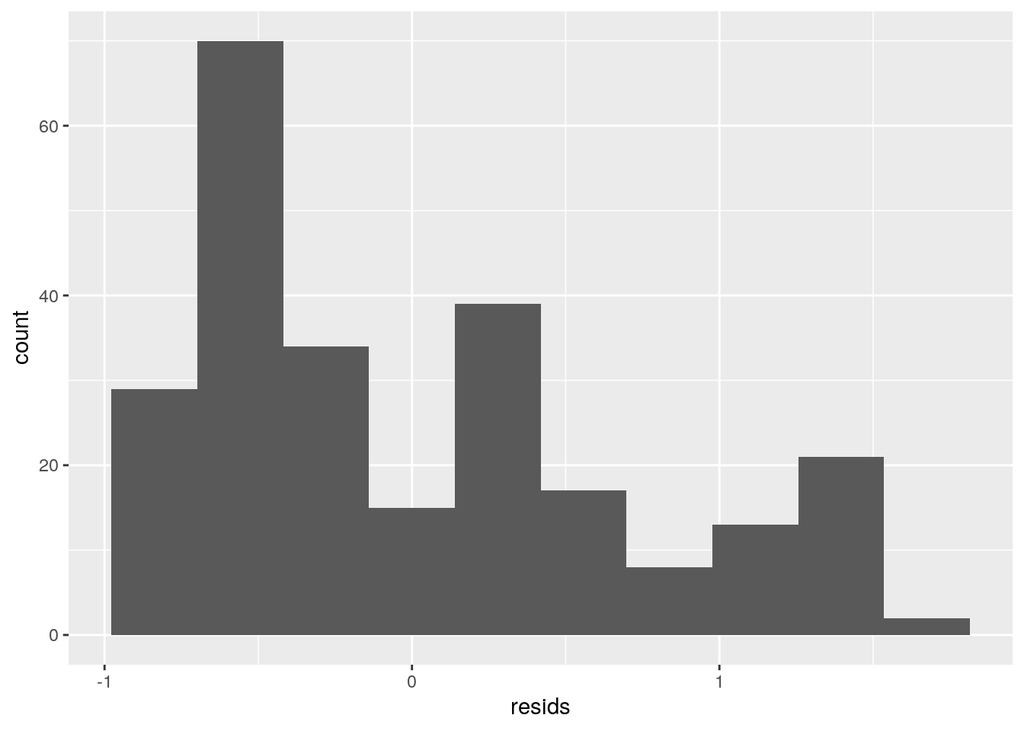

```r
resids <- lm(spontaneous ~ age + induced, data = abortData)$residuals
ggplot() + geom_histogram(aes(resids), bins = 10)
```

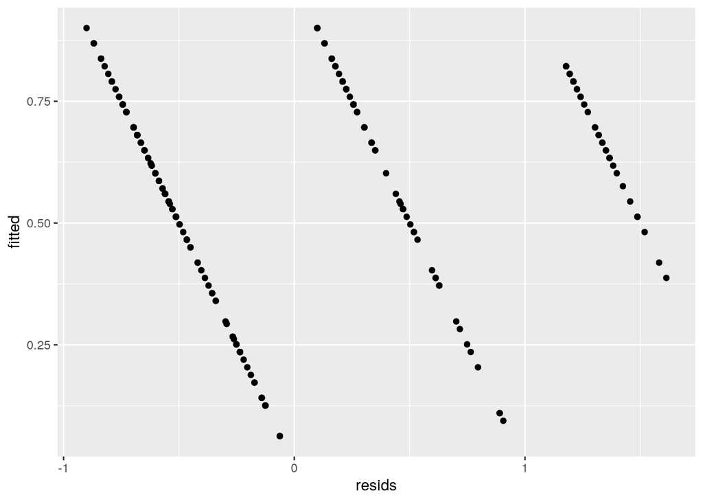

```r
fitted <- lm(spontaneous ~ age + induced, data = abortData)$fitted.values
ggplot() + geom_point(aes(resids, fitted))
```

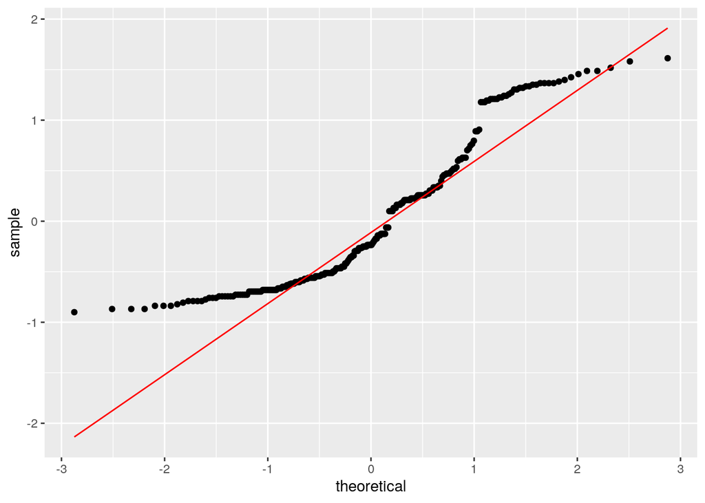

```r
ggplot() + geom_qq(aes(sample = resids)) + geom_qq_line(aes(sample = resids),
    color = "red")
```